# SI_02_GRANT_US_ORG_ADDR_ZIP

Grantee zip · Identifier report

## Overview

**Description**

Address Foreign - Postal code

**Table**

`SI-P02-T01-GRANTS-US-ORGS-GOVTS` (many)

**Location code**

`SCHED-I-PART-02-LINE-01-COL-A`

**Family**

`SCHED-I-PART-02-LINE-01-COL-A` · siblings: SI_02_GRANT_US_ORG_ADDR_CITY, SI_02_GRANT_US_ORG_ADDR_CNTR, SI_02_GRANT_US_ORG_ADDR_L1, SI_02_GRANT_US_ORG_ADDR_L2, SI_02_GRANT_US_ORG_ADDR_STATE, SI_02_GRANT_US_ORG_NAME_L1

**Data type**

text (xsd: , TextType, ZIPCodeType)

**Scope**

PC

**Status**

unreviewed

8

xpaths mapped (6 observed)

531,105

filings with a value

2009–2024

tax years observed

3

open flags (1 errors)

## Flags

| Severity | Flag | Xpath | Detail |
| --- | --- | --- | --- |
| ⚠ error | `COLLISION` | IRS990ScheduleI/RecipientTable/ForeignAddress/ForeignPostalCd | 1139 filings contain 2+ of its xpaths; most common set: /Return/ReturnData/IRS990ScheduleI/RecipientTable/ForeignAddress/ForeignPostalCd ; /Return/ReturnData/IRS990ScheduleI/RecipientTable/USAddress/Z… |
| ⓘ info | `UNOBSERVED` | IRS990ScheduleI/Form990ScheduleIPartII/RecipientTable/AddressForeign/PostalCode | never observed in TY2009-2024 filings |
| ⓘ info | `UNOBSERVED` | IRS990ScheduleI/Form990ScheduleIPartII/RecipientTable/AddressUS/ZIPCode | never observed in TY2009-2024 filings |

## Xpaths

All mapped xpaths (under /Return/ReturnData or /Return/ReturnHeader), oldest first. Charts label each series by its xpath.

| Xpath | Form | Chart label | First year | Last year | Versions | Filings | Repeats in |
| --- | --- | --- | --- | --- | --- | --- | --- |
| IRS990ScheduleI/RecipientTable/AddressUS/ZIPCode | Sched I | same | 2009 | 2012 | 18 | 68,775 | 51.5% |
| IRS990ScheduleI/RecipientTable/AddressForeign/PostalCode | Sched I | same | 2009 | 2012 | 11 | 134 | 19.4% |
| IRS990ScheduleI/RecipientTable/USAddress/ZIPCode | Sched I | same | 2013 | 2013 | 3 | 27,474 | 50.2% |
| IRS990ScheduleI/RecipientTable/ForeignAddress/PostalCode | Sched I | same | 2013 | 2013 | 3 | 57 | 14.0% |
| IRS990ScheduleI/RecipientTable/USAddress/ZIPCd | Sched I | same | 2014 | 2024 | 34 | 433,436 | 50.9% |
| IRS990ScheduleI/RecipientTable/ForeignAddress/ForeignPostalCd | Sched I | …90ScheduleI/RecipientTable/ForeignAddress/ForeignPostalCd | 2014 | 2024 | 33 | 1,229 | 21.4% |
| IRS990ScheduleI/Form990ScheduleIPartII/RecipientTable/AddressForeign/PostalCode | Sched I | …0ScheduleIPartII/RecipientTable/AddressForeign/PostalCode |  |  |  | 0 |  |
| IRS990ScheduleI/Form990ScheduleIPartII/RecipientTable/AddressUS/ZIPCode | Sched I | …I/Form990ScheduleIPartII/RecipientTable/AddressUS/ZIPCode |  |  |  | 0 |  |

## Coverage

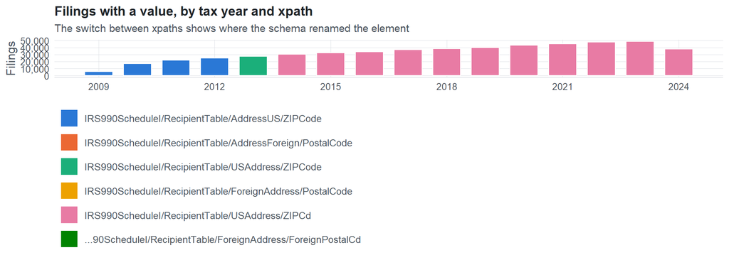

**Table view**

Table view: filings by tax year and series

| Tax year | IRS990ScheduleI/RecipientTable/AddressUS/ZIPCode | IRS990ScheduleI/RecipientTable/AddressForeign/PostalCode | IRS990ScheduleI/RecipientTable/USAddress/ZIPCode | IRS990ScheduleI/RecipientTable/ForeignAddress/PostalCode | IRS990ScheduleI/RecipientTable/USAddress/ZIPCd | …90ScheduleI/RecipientTable/ForeignAddress/ForeignPostalCd |
| --- | --- | --- | --- | --- | --- | --- |
| 2009 | 5,375 | 10 | 0 | 0 | 0 | 0 |
| 2010 | 16,862 | 32 | 0 | 0 | 0 | 0 |
| 2011 | 21,884 | 43 | 0 | 0 | 0 | 0 |
| 2012 | 24,654 | 49 | 0 | 0 | 0 | 0 |
| 2013 | 0 | 0 | 27,474 | 57 | 0 | 0 |
| 2014 | 0 | 0 | 0 | 0 | 30,396 | 65 |
| 2015 | 0 | 0 | 0 | 0 | 32,477 | 60 |
| 2016 | 0 | 0 | 0 | 0 | 33,945 | 88 |
| 2017 | 0 | 0 | 0 | 0 | 36,928 | 111 |
| 2018 | 0 | 0 | 0 | 0 | 38,292 | 104 |
| 2019 | 0 | 0 | 0 | 0 | 39,702 | 95 |
| 2020 | 0 | 0 | 0 | 0 | 43,091 | 117 |
| 2021 | 0 | 0 | 0 | 0 | 44,833 | 152 |
| 2022 | 0 | 0 | 0 | 0 | 47,425 | 160 |
| 2023 | 0 | 0 | 0 | 0 | 48,715 | 154 |
| 2024 | 0 | 0 | 0 | 0 | 37,632 | 123 |

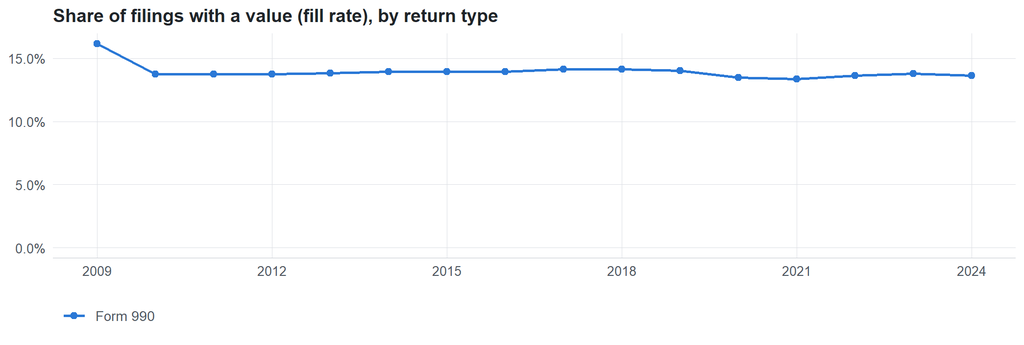

**Table view**

Table view: fill rate

| Tax year | Return type | Filings | All filings | Fill rate |
| --- | --- | --- | --- | --- |
| 2009 | Form 990 | 5,385 | 33,311 | 16.17% |
| 2010 | Form 990 | 16,894 | 123,025 | 13.73% |
| 2011 | Form 990 | 21,927 | 159,504 | 13.75% |
| 2012 | Form 990 | 24,703 | 179,688 | 13.75% |
| 2013 | Form 990 | 27,531 | 198,855 | 13.84% |
| 2014 | Form 990 | 30,461 | 218,619 | 13.93% |
| 2015 | Form 990 | 32,537 | 233,519 | 13.93% |
| 2016 | Form 990 | 34,033 | 243,903 | 13.95% |
| 2017 | Form 990 | 37,039 | 261,612 | 14.16% |
| 2018 | Form 990 | 38,396 | 271,442 | 14.15% |
| 2019 | Form 990 | 39,797 | 283,694 | 14.03% |
| 2020 | Form 990 | 43,208 | 320,342 | 13.49% |
| 2021 | Form 990 | 44,985 | 336,480 | 13.37% |
| 2022 | Form 990 | 47,585 | 349,055 | 13.63% |
| 2023 | Form 990 | 48,869 | 354,768 | 13.77% |
| 2024 | Form 990 | 37,755 | 277,298 | 13.62% |

## Repeating groups

Table cardinality in the concordance: **many**. 6 of 6 observed xpaths repeat within a filing.

Repeating element each xpath was observed in (from the raw indexed xpath)

| Xpath | Repeating element | Filings (summed over years) |
| --- | --- | --- |
| IRS990ScheduleI/RecipientTable/AddressForeign/PostalCode | (none) | 19 |
| IRS990ScheduleI/RecipientTable/AddressForeign/PostalCode | IRS990ScheduleI/RecipientTable | 115 |
| IRS990ScheduleI/RecipientTable/AddressUS/ZIPCode | (none) | 32903 |
| IRS990ScheduleI/RecipientTable/AddressUS/ZIPCode | IRS990ScheduleI/RecipientTable | 35872 |
| IRS990ScheduleI/RecipientTable/ForeignAddress/PostalCode | (none) | 12 |
| IRS990ScheduleI/RecipientTable/ForeignAddress/PostalCode | IRS990ScheduleI/RecipientTable | 45 |
| IRS990ScheduleI/RecipientTable/USAddress/ZIPCode | (none) | 13507 |
| IRS990ScheduleI/RecipientTable/USAddress/ZIPCode | IRS990ScheduleI/RecipientTable | 13967 |
| IRS990ScheduleI/RecipientTable/ForeignAddress/ForeignPostalCd | (none) | 190 |
| IRS990ScheduleI/RecipientTable/ForeignAddress/ForeignPostalCd | IRS990ScheduleI/RecipientTable | 1039 |
| IRS990ScheduleI/RecipientTable/USAddress/ZIPCd | (none) | 210459 |
| IRS990ScheduleI/RecipientTable/USAddress/ZIPCd | IRS990ScheduleI/RecipientTable | 222977 |

## Values

| Result | Check | Detail |
| --- | --- | --- |
| ✓ pass | Values have the ZIP format | 99.9% of values match ^(99999\|999999999\|99999-9999)$ |
| ✓ pass | Stored as text | data type is text |
| ▲ warn | No placeholder values | 6 filings use a placeholder such as 000000000 |
| ⓘ info | Leading zeros present | at least 1% of values start with 0 in some year, so numeric storage would change them |

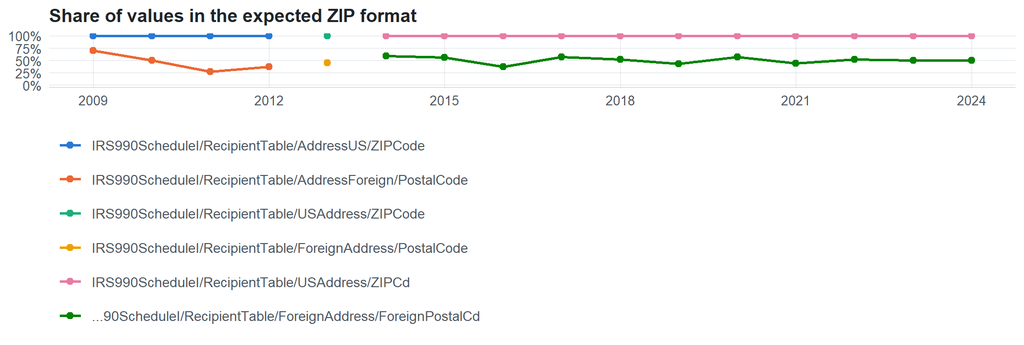

Value shapes (9 = digit, A = letter)

| Series | Shape | Expected | Filings |
| --- | --- | --- | --- |
| IRS990ScheduleI/RecipientTable/AddressUS/ZIPCode | 99999 | yes | 66,467 |
| IRS990ScheduleI/RecipientTable/AddressUS/ZIPCode | 999999999 | yes | 7,538 |
| IRS990ScheduleI/RecipientTable/AddressForeign/PostalCode | 99999 | yes | 38 |
| IRS990ScheduleI/RecipientTable/AddressForeign/PostalCode | A9A 9A9 | no | 30 |
| IRS990ScheduleI/RecipientTable/AddressForeign/PostalCode | 9999 | no | 10 |
| IRS990ScheduleI/RecipientTable/AddressForeign/PostalCode | 999999 | no | 8 |
| IRS990ScheduleI/RecipientTable/AddressForeign/PostalCode | A9A9A9 | no | 5 |
| IRS990ScheduleI/RecipientTable/AddressForeign/PostalCode | AA9 9AA | no | 5 |
| IRS990ScheduleI/RecipientTable/AddressForeign/PostalCode | 99999-9999 | yes | 3 |
| IRS990ScheduleI/RecipientTable/AddressForeign/PostalCode | 9999999999 | no | 2 |
| IRS990ScheduleI/RecipientTable/USAddress/ZIPCode | 99999 | yes | 26,648 |
| IRS990ScheduleI/RecipientTable/USAddress/ZIPCode | 999999999 | yes | 2,738 |
| IRS990ScheduleI/RecipientTable/ForeignAddress/PostalCode | 99999 | yes | 19 |
| IRS990ScheduleI/RecipientTable/ForeignAddress/PostalCode | A9A 9A9 | no | 9 |
| IRS990ScheduleI/RecipientTable/ForeignAddress/PostalCode | 999999 | no | 6 |
| IRS990ScheduleI/RecipientTable/ForeignAddress/PostalCode | 999 | no | 4 |
| IRS990ScheduleI/RecipientTable/ForeignAddress/PostalCode | 9999 | no | 4 |
| IRS990ScheduleI/RecipientTable/USAddress/ZIPCd | 99999 | yes | 422,631 |
| IRS990ScheduleI/RecipientTable/USAddress/ZIPCd | 999999999 | yes | 40,285 |
| IRS990ScheduleI/RecipientTable/USAddress/ZIPCd | 999999999999 | no | 1 |
| …90ScheduleI/RecipientTable/ForeignAddress/ForeignPostalCd | 99999 | yes | 473 |
| …90ScheduleI/RecipientTable/ForeignAddress/ForeignPostalCd | A9A 9A9 | no | 200 |
| …90ScheduleI/RecipientTable/ForeignAddress/ForeignPostalCd | 9999 | no | 96 |
| …90ScheduleI/RecipientTable/ForeignAddress/ForeignPostalCd | 999999 | no | 91 |
| …90ScheduleI/RecipientTable/ForeignAddress/ForeignPostalCd | A9A9A9 | no | 53 |
| …90ScheduleI/RecipientTable/ForeignAddress/ForeignPostalCd | 9999999 | no | 21 |
| …90ScheduleI/RecipientTable/ForeignAddress/ForeignPostalCd | AA9 9AA | no | 17 |
| …90ScheduleI/RecipientTable/ForeignAddress/ForeignPostalCd | 99999-9999 | yes | 16 |
| …90ScheduleI/RecipientTable/ForeignAddress/ForeignPostalCd | AAA 9999 | no | 4 |

## Examples

| Tax year | Return | Xpath | Organization | Value | Source |
| --- | --- | --- | --- | --- | --- |
| 2024 | 990 | IRS990ScheduleI/RecipientTable/ForeignAddress/ForeignPostalCd | EDUCATIONAL CREDIT | 00717 | [XML](https://gt990datalake-rawdata.s3.amazonaws.com/EfileData/XmlFiles/202503199349301740_public.xml) |
| 2024 | 990 | IRS990ScheduleI/RecipientTable/USAddress/ZIPCd | THE CLEVELAND CLINIC FOUNDATION | 33309 | [XML](https://gt990datalake-rawdata.s3.amazonaws.com/EfileData/XmlFiles/202513189349302136_public.xml) |
| 2023 | 990 | IRS990ScheduleI/RecipientTable/ForeignAddress/ForeignPostalCd | COANIQUEM BURN CENTER AID | 8050000 | [XML](https://gt990datalake-rawdata.s3.amazonaws.com/EfileData/XmlFiles/202441239349302764_public.xml) |
| 2023 | 990 | IRS990ScheduleI/RecipientTable/USAddress/ZIPCd | LOUISVILLE PROFESSIONAL FIREFIGHTERS | 60607 | [XML](https://gt990datalake-rawdata.s3.amazonaws.com/EfileData/XmlFiles/202423209349320882_public.xml) |
| 2022 | 990 | IRS990ScheduleI/RecipientTable/ForeignAddress/ForeignPostalCd | IHC HEALTH SERVICES INC | 01021 | [XML](https://gt990datalake-rawdata.s3.amazonaws.com/EfileData/XmlFiles/202313159349300546_public.xml) |
| 2022 | 990 | IRS990ScheduleI/RecipientTable/USAddress/ZIPCd | HOUSTON PRODUCERS’ FORUM | 767987050 | [XML](https://gt990datalake-rawdata.s3.amazonaws.com/EfileData/XmlFiles/202321309349304417_public.xml) |
| 2021 | 990 | IRS990ScheduleI/RecipientTable/ForeignAddress/ForeignPostalCd | THE SOCIETY OF THE MISSIONARIES OF | 02383 | [XML](https://gt990datalake-rawdata.s3.amazonaws.com/EfileData/XmlFiles/202213199349317426_public.xml) |
| 2021 | 990 | IRS990ScheduleI/RecipientTable/USAddress/ZIPCd | CAMP JOHN MARC FOUNDATION INC | 75206 | [XML](https://gt990datalake-rawdata.s3.amazonaws.com/EfileData/XmlFiles/202241039349300339_public.xml) |
| 2020 | 990 | IRS990ScheduleI/RecipientTable/ForeignAddress/ForeignPostalCd | HUNTER COLLEGE ELEMENTARY SCHOOL PARENT | W67EB | [XML](https://gt990datalake-rawdata.s3.amazonaws.com/EfileData/XmlFiles/202231369349314938_public.xml) |
| 2020 | 990 | IRS990ScheduleI/RecipientTable/USAddress/ZIPCd | GREATER FARGO MOORHEAD ECONOMIC | 58104 | [XML](https://gt990datalake-rawdata.s3.amazonaws.com/EfileData/XmlFiles/202102679349301200_public.xml) |
| 2019 | 990 | IRS990ScheduleI/RecipientTable/ForeignAddress/ForeignPostalCd | Musaadah Charity | 1207 | [XML](https://gt990datalake-rawdata.s3.amazonaws.com/EfileData/XmlFiles/202033169349305518_public.xml) |
| 2019 | 990 | IRS990ScheduleI/RecipientTable/USAddress/ZIPCd | Knights of Columbus | 89060 | [XML](https://gt990datalake-rawdata.s3.amazonaws.com/EfileData/XmlFiles/202110719349300911_public.xml) |

## Reviewer checklist

- The definition matches the form line and instructions for every xpath’s schema years.
- Every xpath pooled here measures the same thing on the 990 and 990-EZ (close enough for analysis).
- The coverage chart has no unexplained gaps or jumps between tax years.
- Each open flag is fixed, or accepted with a note in validation_log.csv.
- The data type is text so leading zeros and letters survive.
- The identifier belongs to the entity the variable names (the filer, preparer, related organization…).
- Formats with and without punctuation (e.g. ZIP+4, dashes) are normalized consistently downstream.

Record the review as a row in `inst/extdata/src/validation_log.csv` (variable_name, reviewer, date, status, note). Evidence built 2026-09-23 17:09:04 MST from the ef2 DuckDB builds (tax years 2009–2024).